# SUBRAMANIAM_PGP_AIML_MARCH2020

```python
import pandas as pd
from sklearn.model_selection import train_test_split
from sklearn.neighbors import KNeighborsClassifier
from sklearn.preprocessing import StandardScaler
from sklearn.naive_bayes import GaussianNB
from sklearn.linear_model import LogisticRegression
from sklearn.metrics import confusion_matrix,classification_report,recall_score,precision_score,f1_score
from sklearn.model_selection import KFold, cross_val_score
from sklearn import model_selection
from sklearn.preprocessing import PolynomialFeatures
from sklearn.preprocessing import PowerTransformer
pt = PowerTransformer()
sc = StandardScaler()
import seaborn as sns
import warnings
import numpy as np
import matplotlib.pyplot as plt
warnings.filterwarnings('ignore')
```

```python
df=pd.read_csv("C:/ML/sup+learning/Bank_Personal_Loan_Modelling-1 (1).csv")
```

```python
df.head()
```

|  | ID | Age | Experience | Income | ZIP Code | Family | CCAvg | Education | Mortgage | Personal Loan | Securities Account | CD Account | Online | CreditCard |
| --- | --- | --- | --- | --- | --- | --- | --- | --- | --- | --- | --- | --- | --- | --- |
| 0 | 1 | 25 | 1 | 49 | 91107 | 4 | 1.6 | 1 | 0 | 0 | 1 | 0 | 0 | 0 |
| 1 | 2 | 45 | 19 | 34 | 90089 | 3 | 1.5 | 1 | 0 | 0 | 1 | 0 | 0 | 0 |
| 2 | 3 | 39 | 15 | 11 | 94720 | 1 | 1.0 | 1 | 0 | 0 | 0 | 0 | 0 | 0 |
| 3 | 4 | 35 | 9 | 100 | 94112 | 1 | 2.7 | 2 | 0 | 0 | 0 | 0 | 0 | 0 |
| 4 | 5 | 35 | 8 | 45 | 91330 | 4 | 1.0 | 2 | 0 | 0 | 0 | 0 | 0 | 1 |

### Read the column description and ensure you understand each attribute well

```python
df.describe()
```

|  | ID | Age | Experience | Income | ZIP Code | Family | CCAvg | Education | Mortgage | Personal Loan | Securities Account | CD Account | Online | CreditCard |
| --- | --- | --- | --- | --- | --- | --- | --- | --- | --- | --- | --- | --- | --- | --- |
| count | 5000.000000 | 5000.000000 | 5000.000000 | 5000.000000 | 5000.000000 | 5000.000000 | 5000.000000 | 5000.000000 | 5000.000000 | 5000.000000 | 5000.000000 | 5000.00000 | 5000.000000 | 5000.000000 |
| mean | 2500.500000 | 45.338400 | 20.104600 | 73.774200 | 93152.503000 | 2.396400 | 1.937938 | 1.881000 | 56.498800 | 0.096000 | 0.104400 | 0.06040 | 0.596800 | 0.294000 |
| std | 1443.520003 | 11.463166 | 11.467954 | 46.033729 | 2121.852197 | 1.147663 | 1.747659 | 0.839869 | 101.713802 | 0.294621 | 0.305809 | 0.23825 | 0.490589 | 0.455637 |
| min | 1.000000 | 23.000000 | -3.000000 | 8.000000 | 9307.000000 | 1.000000 | 0.000000 | 1.000000 | 0.000000 | 0.000000 | 0.000000 | 0.00000 | 0.000000 | 0.000000 |
| 25% | 1250.750000 | 35.000000 | 10.000000 | 39.000000 | 91911.000000 | 1.000000 | 0.700000 | 1.000000 | 0.000000 | 0.000000 | 0.000000 | 0.00000 | 0.000000 | 0.000000 |
| 50% | 2500.500000 | 45.000000 | 20.000000 | 64.000000 | 93437.000000 | 2.000000 | 1.500000 | 2.000000 | 0.000000 | 0.000000 | 0.000000 | 0.00000 | 1.000000 | 0.000000 |
| 75% | 3750.250000 | 55.000000 | 30.000000 | 98.000000 | 94608.000000 | 3.000000 | 2.500000 | 3.000000 | 101.000000 | 0.000000 | 0.000000 | 0.00000 | 1.000000 | 1.000000 |
| max | 5000.000000 | 67.000000 | 43.000000 | 224.000000 | 96651.000000 | 4.000000 | 10.000000 | 3.000000 | 635.000000 | 1.000000 | 1.000000 | 1.00000 | 1.000000 | 1.000000 |

We can infer from the above stastics that , there are categorical and numerical attributes of each customers of the bank are listed, we can see few ouliers are present in the distributions hence the distibutions are skewed, experience column seems to have negative values which is not possible in the real world scenario, hence we have to work towards resolving it, and adress the skewness of the distribuitons while building our models

```python
df.shape
```

```
(5000, 14)
```

```python
filt=df['Experience']<0
negative_rows=df.loc[filt]
negative_rows.shape
```

```
(52, 14)
```

```python
df['Experience']=df['Experience'].abs()
```

```python
filt=df['Experience']<0
df.loc[filt]
```

|  | ID | Age | Experience | Income | ZIP Code | Family | CCAvg | Education | Mortgage | Personal Loan | Securities Account | CD Account | Online | CreditCard |
| --- | --- | --- | --- | --- | --- | --- | --- | --- | --- | --- | --- | --- | --- | --- |

```python
df.isnull().sum()
```

```
ID                    0
Age                   0
Experience            0
Income                0
ZIP Code              0
Family                0
CCAvg                 0
Education             0
Mortgage              0
Personal Loan         0
Securities Account    0
CD Account            0
Online                0
CreditCard            0
dtype: int64
```

### Study the data distribution in each attribute, share your findings

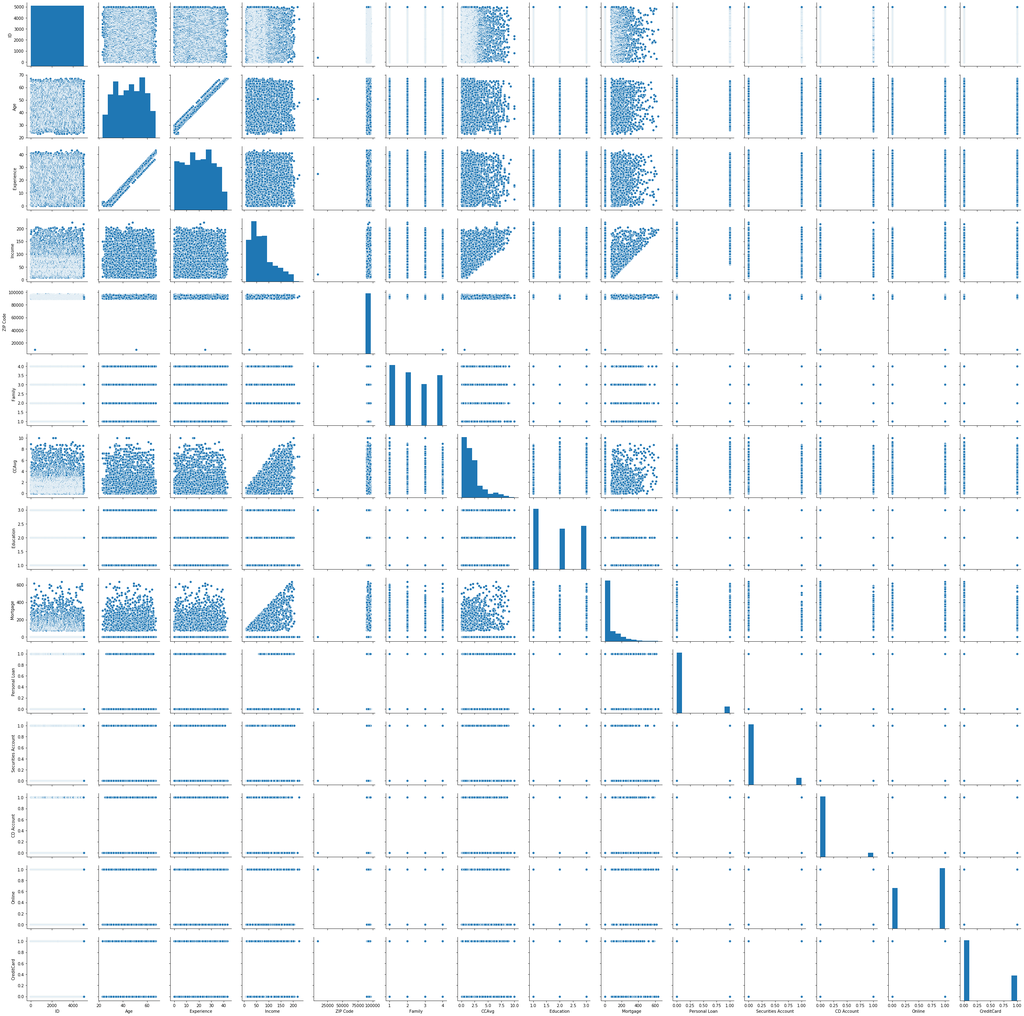

```python
sns.pairplot(df)
```

We can infer that the CCAvg and the Income column are heavily right skewed , this may affect the model perfromance while building models hence we can use the power transformer method to reduce the skewness and improve our model efficency

```python
col=['ZIP Code','ID','Personal Loan']
X=df.drop(col,axis=1)
X.head()
```

|  | Age | Experience | Income | Family | CCAvg | Education | Mortgage | Securities Account | CD Account | Online | CreditCard |
| --- | --- | --- | --- | --- | --- | --- | --- | --- | --- | --- | --- |
| 0 | 25 | 1 | 49 | 4 | 1.6 | 1 | 0 | 1 | 0 | 0 | 0 |
| 1 | 45 | 19 | 34 | 3 | 1.5 | 1 | 0 | 1 | 0 | 0 | 0 |
| 2 | 39 | 15 | 11 | 1 | 1.0 | 1 | 0 | 0 | 0 | 0 | 0 |
| 3 | 35 | 9 | 100 | 1 | 2.7 | 2 | 0 | 0 | 0 | 0 | 0 |
| 4 | 35 | 8 | 45 | 4 | 1.0 | 2 | 0 | 0 | 0 | 0 | 1 |

### Get the target column distribution. Your comments.

```python
y=df['Personal Loan']
y.head()
```

```
0    0
1    0
2    0
3    0
4    0
Name: Personal Loan, dtype: int64
```

```python
y.value_counts()
```

```
0    4520
1     480
Name: Personal Loan, dtype: int64
```

The personal loan categorical column is our target column, it has its values interms of 1 and 0, also we can observe that there is class imbalance in our data by a ratio of 90.4% to 9.6% so this can also contribute to the performance of our model, since our model can learn the '0' class very well compared to '1' class

### Split the data into training and test set in the ratio of 70:30 respectively

### Use different classification models (Logistic, K-NN and Naïve Bayes) to predict the

### likelihood of a liability customer buying personal loans

### Print the confusion matrix for all the above models

```python
poly=PolynomialFeatures(degree=3)
```

```python
import time
```

Since we need to find the ideal value of number of 'n-neighbours' we use the following iterative method to access the parameter based on 'accuracy' and 'f1 score'

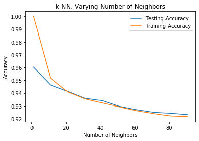

```
556.7380316257477
```

```python
t0 = time.time()
neighbors = np.arange(1, 100,10)
train_accuracy_plot = np.empty(len(neighbors))
test_accuracy_plot = np.empty(len(neighbors))
# Loop over different values of k
for i, k in enumerate(neighbors):
    train = []
    test = []
    for j in range(5):
        X_train, X_test, y_train, y_test = train_test_split(X, y, test_size=0.30,random_state=j)
        scaledX_train = pt.fit_transform(X_train)
        scaledX_test = pt.transform(X_test)
        poly_X_Train=poly.fit_transform(scaledX_train)
        poly_X_Test=poly.transform(scaledX_test)
        knn = KNeighborsClassifier(n_neighbors=k)
        knn.fit(poly_X_Train,y_train)
        train.append(knn.score(poly_X_Train,y_train))
        test.append(knn.score(poly_X_Test,y_test))
    #Compute accuracy on the training set
    train_accuracy_plot[i] = np.mean(train)
    #Compute accuracy on the testing set
    test_accuracy_plot[i] = np.mean(test)
# Generate plot
plt.title('k-NN: Varying Number of Neighbors')
plt.plot(neighbors, test_accuracy_plot, label = 'Testing Accuracy')
plt.plot(neighbors, train_accuracy_plot, label = 'Training Accuracy')
plt.legend()
plt.xlabel('Number of Neighbors')
plt.ylabel('Accuracy')
plt.show()
t1 = time.time()
print(t1-t0)
```

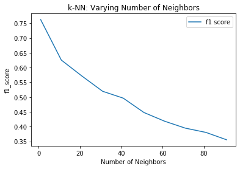

```
177.9967713356018
```

```python
t0 = time.time()
neighbors = np.arange(1, 100,10)
train_accuracy_plot = np.empty(len(neighbors))
test_accuracy_plot = np.empty(len(neighbors))
f1_plot=np.empty(len(neighbors))
# Loop over different values of k
for i, k in enumerate(neighbors):
    train = []
    test = []
    f1=[]
    for j in range(5):
        X_train, X_test, y_train, y_test = train_test_split(X, y, test_size=0.30,random_state=j)
        scaledX_train = pt.fit_transform(X_train)
        scaledX_test = pt.transform(X_test)
        poly_X_Train=poly.fit_transform(scaledX_train)
        poly_X_Test=poly.transform(scaledX_test)
        knn = KNeighborsClassifier(n_neighbors=k)
        knn.fit(poly_X_Train,y_train)
        predicted=knn.predict(poly_X_Test)
        f1.append(f1_score(y_test,predicted, average=None)[1])
        f1_plot[i] = np.mean(f1)

# Generate plot
plt.title('k-NN: Varying Number of Neighbors')
plt.plot(neighbors,f1_plot, label = 'f1 score')
# plt.plot(neighbors, train_accuracy_plot, label = 'Training Accuracy')
plt.legend()
plt.xlabel('Number of Neighbors')
plt.ylabel('f1_score')
plt.show()
t1 = time.time()
print(t1-t0)
```

```python
X_train, X_test, y_train, y_test = train_test_split(X, y, test_size=0.30,random_state=42)
scaledX_train = pt.fit_transform(X_train)
scaledX_test = pt.transform(X_test)
poly_X_Train=poly.fit_transform(scaledX_train)
poly_X_Test=poly.transform(scaledX_test)
knn=KNeighborsClassifier(n_neighbors=5,weights='uniform')
knn.fit(poly_X_Train,y_train)
print("What is the Testing Accuracy")
print(knn.score(poly_X_Test,y_test))
print("What is the Training Accuracy")
print(knn.score(poly_X_Train,y_train))
predicted=knn.predict(poly_X_Test)
print(confusion_matrix(y_test,predicted))
print(classification_report(y_test,predicted))
```

```
What is the Testing Accuracy
0.95
What is the Training Accuracy
0.9645714285714285
[[1337    6]
 [  69   88]]
              precision    recall  f1-score   support

           0       0.95      1.00      0.97      1343
           1       0.94      0.56      0.70       157

    accuracy                           0.95      1500
   macro avg       0.94      0.78      0.84      1500
weighted avg       0.95      0.95      0.94      1500
```

```python
X_train, X_test, y_train, y_test = train_test_split(X, y, test_size=0.30,random_state=42)
scaledX_train = pt.fit_transform(X_train)
scaledX_test = pt.transform(X_test)
poly_X_Train=poly.fit_transform(scaledX_train)
poly_X_Test=poly.transform(scaledX_test)
lr=LogisticRegression()
lr.fit(poly_X_Train,y_train)
print("What is the Testing Accuracy")
print(lr.score(poly_X_Test,y_test))
print("What is the Training Accuracy")
print(lr.score(poly_X_Train,y_train))
predicted=lr.predict(poly_X_Test)
print(confusion_matrix(y_test,predicted))
print(classification_report(y_test,predicted))
```

```
What is the Testing Accuracy
0.984
What is the Training Accuracy
0.9931428571428571
[[1336    7]
 [  17  140]]
              precision    recall  f1-score   support

           0       0.99      0.99      0.99      1343
           1       0.95      0.89      0.92       157

    accuracy                           0.98      1500
   macro avg       0.97      0.94      0.96      1500
weighted avg       0.98      0.98      0.98      1500
```

```python
X_train, X_test, y_train, y_test = train_test_split(X, y, test_size=0.30,random_state=42)
scaledX_train = pt.fit_transform(X_train)
scaledX_test = pt.transform(X_test)
poly_X_Train=poly.fit_transform(scaledX_train)
poly_X_Test=poly.transform(scaledX_test)
gb=GaussianNB()
gb.fit(poly_X_Train,y_train)
print("What is the Testing Accuracy")
print(gb.score(poly_X_Test,y_test))
print("What is the Training Accuracy")
print(gb.score(poly_X_Train,y_train))
predicted=gb.predict(poly_X_Test)
print(confusion_matrix(y_test,predicted))
print(classification_report(y_test,predicted))
```

```
What is the Testing Accuracy
0.884
What is the Training Accuracy
0.8848571428571429
[[1261   82]
 [  92   65]]
              precision    recall  f1-score   support

           0       0.93      0.94      0.94      1343
           1       0.44      0.41      0.43       157

    accuracy                           0.88      1500
   macro avg       0.69      0.68      0.68      1500
weighted avg       0.88      0.88      0.88      1500
```

### We can conclude from the above individual seprate models that for one seprate runs , the logisticregression model performs

### well as compared to the KNN and Naive Bayes model, so now we will

### perform the cross validation for 10 instances and get the

```python
knn = KNeighborsClassifier(n_neighbors=5,weights='uniform')
lr =  LogisticRegression()
gb=   GaussianNB()
```

```python
models = []
models.append(('knn', knn))
models.append(('lr', lr))
models.append(('gb', gb))
```

```
knn: 0.421126 (0.059557)
lr: 0.725137 (0.069837)
gb: 0.481252 (0.076239)
```

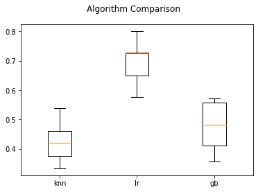

```python
# evaluate each model in turn
results = []
names = []
scoring = 'f1'
for name, model in models:
	kfold = model_selection.KFold(n_splits=10,random_state=42)
	cv_results = model_selection.cross_val_score(model, X, y, cv=kfold, scoring=scoring)
	results.append(cv_results)
	names.append(name)
	msg = "%s: %f (%f)" % (name, np.median(cv_results), cv_results.std())
	print(msg)
# boxplot algorithm comparison
fig = plt.figure()
fig.suptitle('Algorithm Comparison')
ax = fig.add_subplot(111)
plt.boxplot(results)
ax.set_xticklabels(names)
plt.show()
```

```
knn: 0.911000 (0.008535)
lr: 0.950000 (0.006621)
gb: 0.887000 (0.011496)
```

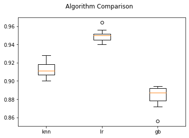

```python
# evaluate each model in turn
results = []
names = []
scoring = 'accuracy'
for name, model in models:
	kfold = model_selection.KFold(n_splits=10,random_state=42)
	cv_results = model_selection.cross_val_score(model, X, y, cv=kfold, scoring=scoring)
	results.append(cv_results)
	names.append(name)
	msg = "%s: %f (%f)" % (name, np.median(cv_results), cv_results.std())
	print(msg)
# boxplot algorithm comparison
fig = plt.figure()
fig.suptitle('Algorithm Comparison')
ax = fig.add_subplot(111)
plt.boxplot(results)
ax.set_xticklabels(names)
plt.show()
```

### Even While running the cross validation, we find out the with an accuracy score of 0.95000 and f1 score of 0.725137 so the LOGISTIC REGRESSION is the best model